# Mapping Servere Weather Events

2024-03-03

## 1 Damage from Storms

### a1) State Level Choropleth Maps

```r
library(tidyverse)
library(sf)
library(maps)
library(ggthemes)
library(scales)
library(RColorBrewer)
library(ggallin)

# ================== Prepare the data ==========================
# Load the storm data from local file
storm_df <- read.csv("storms.csv")

# Convert STATE to lowercase
storm_df <- storm_df %>%
  mutate(
    state = str_to_lower(storm_df$STATE),
    total_damage = DAMAGE_PROPERTY_USD + DAMAGE_CROPS_USD
  )

# Summarize storm damage to state level
storm_damage_state <- storm_df %>%
  group_by(state) %>%
  summarise(total_damage = sum(total_damage, na.rm = TRUE))

# Prepare USA State level data
usa_state <- st_as_sf(map("state", fill=TRUE, plot=FALSE))

# Prepare USA State abbreviation
state_abbr <- data.frame(
  state = str_to_lower(state.name),
  abbr = state.abb
)

# Combine usa state map data and damage data
state_map_data <- usa_state %>%
  left_join(storm_damage_state, by = c("ID" = "state")) %>%
  left_join(state_abbr, by = c("ID" = "state"))

head(state_map_data)
```

```
## Simple feature collection with 6 features and 3 fields
## Geometry type: MULTIPOLYGON
## Dimension:     XY
## Bounding box:  xmin: -124.3834 ymin: 30.24071 xmax: -71.78015 ymax: 42.04937
## Geodetic CRS:  +proj=longlat +ellps=clrk66 +no_defs +type=crs
##            ID total_damage abbr                           geom
## 1     alabama    392049900   AL MULTIPOLYGON (((-87.46201 3...
## 2     arizona    247439150   AZ MULTIPOLYGON (((-114.6374 3...
## 3    arkansas    483290300   AR MULTIPOLYGON (((-94.05103 3...
## 4  california   2222613240   CA MULTIPOLYGON (((-120.006 42...
## 5    colorado    608317740   CO MULTIPOLYGON (((-102.0552 4...
## 6 connecticut     73607710   CT MULTIPOLYGON (((-73.49902 4...
```

Generate state level choropleth maps:

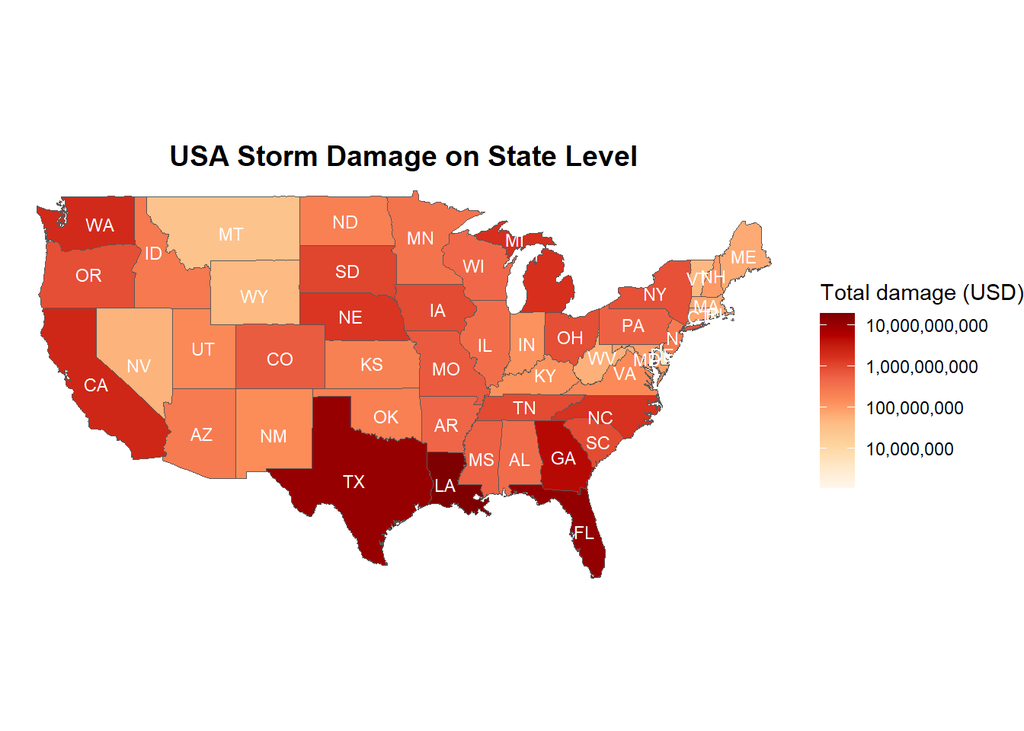

```r
# Generate state level map
ggplot(state_map_data) +
  geom_sf(aes(fill=total_damage)) +
  scale_fill_gradientn(
    "Total damage (USD)",
    colors = brewer.pal(9, "OrRd"), trans = pseudolog10_trans,
    breaks = 10^(7:10), na.value = "grey80", labels=comma) +
  geom_sf_text(aes(label=abbr), size=3, color="white") +
  labs(title = "USA Storm Damage on State Level") +
  theme_void() +
  theme(plot.title=element_text(face="bold", hjust=.5, size=14),
        legend.position = "right")
```

### a2) County Choropleth Maps

First, we prepare the data.

```r
# Prepare storm damage value on county level
storm_damage_county <- storm_df %>%
  mutate(county=paste0(state, ",", str_to_lower(CZ_NAME))) %>%
  group_by(county) %>%
  summarise(total_damage=sum(total_damage, na.rm=T))

# Prepare usa county data
usa_county <- st_as_sf(map("county", fill=TRUE, plot=FALSE))

# Combine usa county map data and damage data
county_map_data <- usa_county %>%
  left_join(storm_damage_county, by = c("ID" = "county"))

head(county_map_data)
```

```
## Simple feature collection with 6 features and 2 fields
## Geometry type: MULTIPOLYGON
## Dimension:     XY
## Bounding box:  xmin: -88.01778 ymin: 30.24071 xmax: -85.06131 ymax: 34.2686
## Geodetic CRS:  +proj=longlat +ellps=clrk66 +no_defs +type=crs
##                ID total_damage                           geom
## 1 alabama,autauga        50000 MULTIPOLYGON (((-86.50517 3...
## 2 alabama,baldwin      2434000 MULTIPOLYGON (((-87.93757 3...
## 3 alabama,barbour        50000 MULTIPOLYGON (((-85.42801 3...
## 4    alabama,bibb            0 MULTIPOLYGON (((-87.02083 3...
## 5  alabama,blount            0 MULTIPOLYGON (((-86.9578 33...
## 6 alabama,bullock        50000 MULTIPOLYGON (((-85.66866 3...
```

Then, we create county choropleth map on county level.

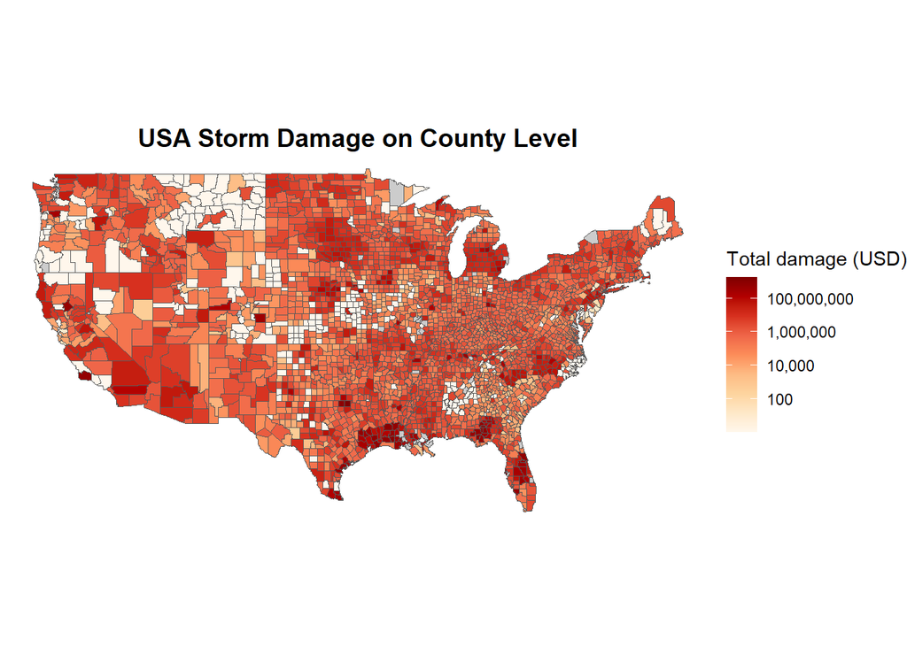

```r
# Generate county choropleth map on county level
ggplot(county_map_data) +
  geom_sf(aes(fill=total_damage)) +
  scale_fill_gradientn(
    "Total damage (USD)",
    colors = brewer.pal(9, "OrRd"), trans = pseudolog10_trans,
    breaks = 10^seq(2,10,2), na.value = "grey80", labels=comma) +
  labs(title = "USA Storm Damage on County Level") +
  theme_void() +
  theme(plot.title = element_text(face="bold", hjust=.5, size=14),
        legend.position = "right")
```

### b) Density Map

Next, we create density map for unjury and death:

```r
# Prepare data
injury_death_df <- storm_df %>%
  mutate(
    lat = (BEGIN_LAT + END_LAT) / 2,
    lon = (BEGIN_LON + END_LON) / 2,
    total_injury = INJURIES_DIRECT + INJURIES_INDIRECT,
    total_death = DEATHS_DIRECT + DEATHS_INDIRECT
  ) %>%
  # Focus on USA continent
  filter(between(lon, -150, -50)) %>%
  filter(total_injury > 0 | total_death > 0) %>%
  dplyr::select(lat, lon, total_injury, total_death)
```

First, we generate density map for injury (Sum of direct injury and indirect injury).

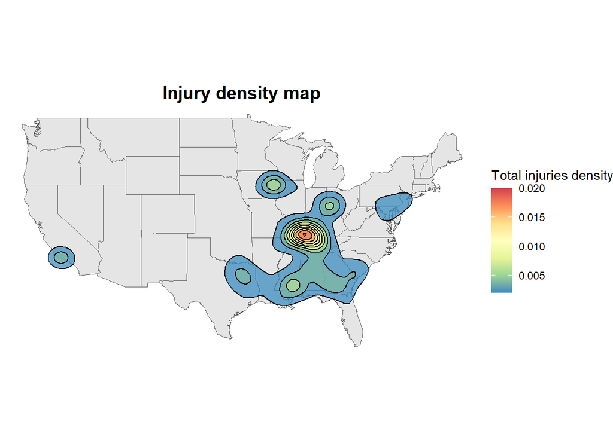

```r
# Repeat rows on total injury
injury_df <- injury_death_df[
  rep(seq_along(injury_death_df$total_injury),
      times=injury_death_df$total_injury), ]

# Generate density plot for injury
ggplot(usa_state) +
  # Background
  geom_sf(fill="grey90") +
  stat_density2d(
    data=injury_df,
    aes(x=lon, y=lat, fill=..level..),
    alpha=.7, geom="polygon", col="black"
  ) +
  scale_fill_gradientn(
    "Total injuries density",
    colours=rev(brewer.pal(7,"Spectral"))) +
  labs(title = "Injury density map") +
  theme_void() +
  theme(plot.title = element_text(face="bold", hjust=.5, size=15))
```

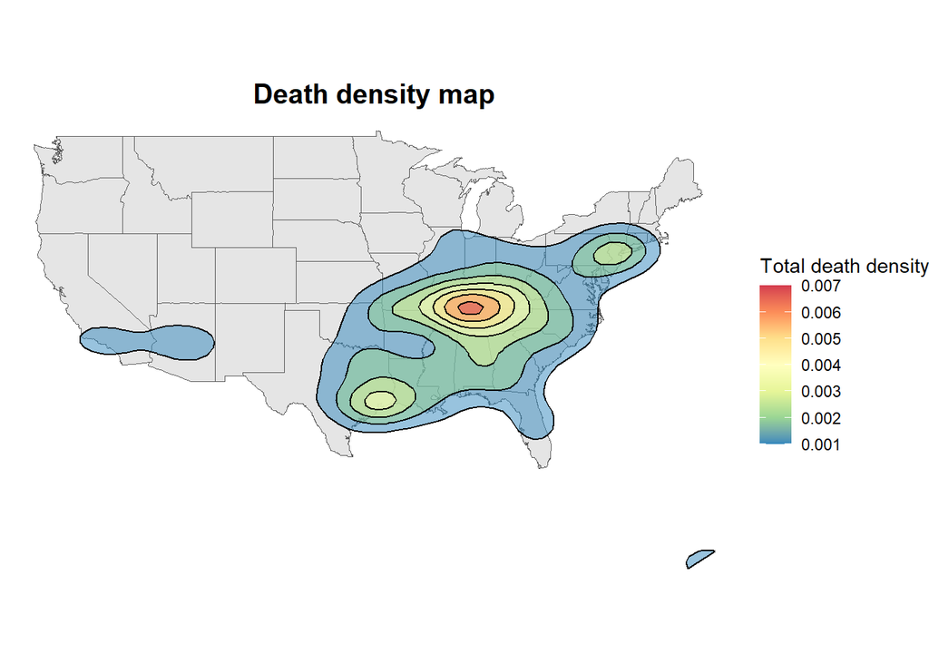

```r
# Repeat rows on total death
death_df <- injury_death_df[
  rep(seq_along(injury_death_df$total_death),
      times=injury_death_df$total_death), ]

# Generate density plot for death
ggplot(usa_state) +
  # Background
  geom_sf(fill="grey90") +
  stat_density2d(
    data=death_df,
    aes(x=lon, y=lat, fill=..level..),
    alpha=.5, geom="polygon", col="black"
  ) +
  scale_fill_gradientn(
    "Total death density",
    colours=rev(brewer.pal(7,"Spectral"))) +
  labs(title = "Death density map") +
  theme_void() +
  theme(plot.title = element_text(face="bold", hjust=.5, size=15))
```

In my view, the detrimental repercussions of the storm manifest through various lenses, encompassing both property damage and casualties. Property losses offer a comprehensive depiction of the storm’s impact, spanning buildings, infrastructure, workforce disruption, transportation, and more, whereas injuries and fatalities underscore personal safety concerns. Comparing these aspects proves challenging. Regarding visualization methods, I find choropleth maps to be more intuitive as they distinctly illustrate losses across different administrative regions, whereas density maps merely provide a broad geographic overview.

## 2. Location of Severe Events

### a) Interactive Map of Severe Weather Events

Create a leaflet map of severe weather events

```r
library(leaflet)

# Prepare weather data set
weather_df <- storm_df %>%
  mutate(
    lon = (BEGIN_LON + END_LON) / 2,
    lat = (BEGIN_LAT + END_LAT) / 2,
    total_death = DEATHS_DIRECT + DEATHS_INDIRECT
  ) %>%
  # Focus on USA mainland
  filter(between(lon, -150, -69)& lat < 55) %>%
  # At least one death
  filter(total_death >= 1)

# Generate leaflet map plot
leaflet() %>%
  addTiles() %>%
  addCircleMarkers(
    lng=weather_df$lon,
    lat=weather_df$lat,
    stroke = FALSE,
    fillOpacity=0.8, radius = 5,
    # Prepare popup information
    popup = paste(
      "Event Type:", weather_df$EVENT_TYPE, "<br>",
      "State:", weather_df$state, "<br>",
      "Damage:", weather_df$total_damage, "<br>",
      "Date:", weather_df$YEAR, ",", weather_df$MONTH_NAME, "<br>",
      "Deaths:", weather_df$total_death, "<br>")
  )
```

[interactive chart not shown]

### b) Color by Type of Weather Event

Next, we will recode event type:

```r
# recode event type
weather_df <- weather_df %>%
  mutate(less_event_type = ifelse(
    EVENT_TYPE %in% c("Waterspout", "Hail", "Marine Thunderstorm Wind",
                      "Debris Flow", "Marine Strong Wind", "Heavy Rain"),
    "Others", EVENT_TYPE))

# Convert weather type to factor
weather_df$less_event_type <- factor(
  weather_df$less_event_type,
  levels=c("Flash Flood", "Thunderstorm Wind", "Flood", "Tornado", "Lightning", "Others")
)
```

Then, create another leaflet map with different color on weather type:

```r
# Different colors on weather type
weather_colors <- c("#464e52", "#d5a991", "#95796c", "#a4a39f", "#688694", "#993719")

leaflet() %>%
  addTiles() %>%
  addCircleMarkers(
    lng=weather_df$lon,
    lat=weather_df$lat,
    color = weather_colors[as.numeric(weather_df$less_event_type)],
    stroke = FALSE, fillOpacity=0.8, radius = 5,
    # Prepare popup information
    popup = paste(
      "Event Type:", weather_df$EVENT_TYPE, "<br>",
      "State:", weather_df$state, "<br>",
      "Damage:", weather_df$total_damage, "<br>",
      "Date:", weather_df$YEAR, ",", weather_df$MONTH_NAME, "<br>",
      "Deaths:", weather_df$total_death, "<br>")
  ) %>%
  addLegend(
    position = "bottomleft",
    colors = weather_colors,
    labels = levels(weather_df$less_event_type),
    title = "Weather type"
  )
```

[interactive chart not shown]

### c) Cluster

```r
leaflet() %>%
  addTiles() %>%
  addCircleMarkers(
    lng=weather_df$lon,
    lat=weather_df$lat,
    color = weather_colors[as.numeric(weather_df$less_event_type)],
    stroke = FALSE, fillOpacity=0.8, radius = 8,
    # Add Cluster on leaflet map
    clusterOptions = markerClusterOptions(),
    # Prepare popup information
    popup = paste(
      "Event Type:", weather_df$EVENT_TYPE, "<br>",
      "State:", weather_df$state, "<br>",
      "Damage:", weather_df$total_damage, "<br>",
      "Date:", weather_df$YEAR, ",", weather_df$MONTH_NAME, "<br>",
      "Deaths:", weather_df$total_death, "<br>")
  ) %>%
  addLegend(
    position = "bottomleft",
    colors = weather_colors,
    labels = levels(weather_df$less_event_type),
    title = "Weather type"
  )
```

[interactive chart not shown]

## 3. Severe Events and Cities

```r
library(geosphere)

# Load city data from given link
cities <- read_csv("us-cities-top-1k.csv") %>%
  # Find the top 100 city by population
  arrange(-Population) %>%
  head(100)

# Find the nearest city for all weather event
nearest_city <- list()
for (i in 1:nrow(weather_df)) {
  weather_coord <- c(weather_df$lon[i], weather_df$lat[i])

  all_distance <- sapply(1:100, function(x) {
    distGeo(weather_coord, c(cities$lon[x], cities$lat[x]))
  })

  nearest_city[[i]] <- cities$City[which.min(all_distance)]
}

weather_df$nearest_city <- unlist(nearest_city)

weather_df <- left_join(
  weather_df,
  select(cities, City, State, Population),
  by = c('nearest_city'='City')
)
```

Next, we will generate a scatter plot showing the relationship between the weather event impact and city population.

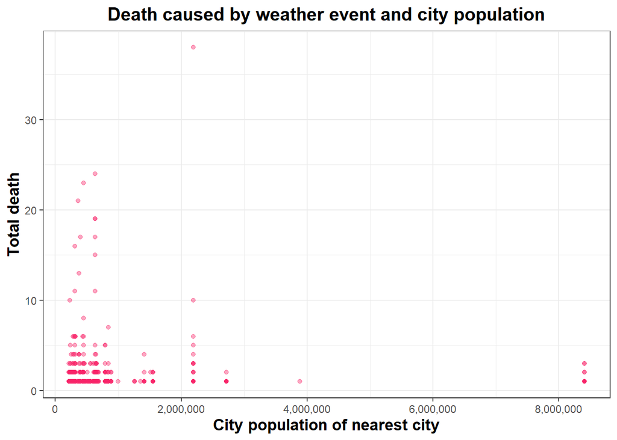

```r
# Generate scatter plot
ggplot(weather_df, aes(x=Population, y=total_death)) +
  geom_point(col="#f72267", alpha=.4) +
  scale_x_continuous(labels=comma) +
  labs(x="City population of nearest city", y="Total death",
       title="Death caused by weather event and city population") +
  theme_bw() +
  theme(plot.title = element_text(size=15, hjust=.5, face="bold"),
        axis.title = element_text(size=13, face="bold"))
```

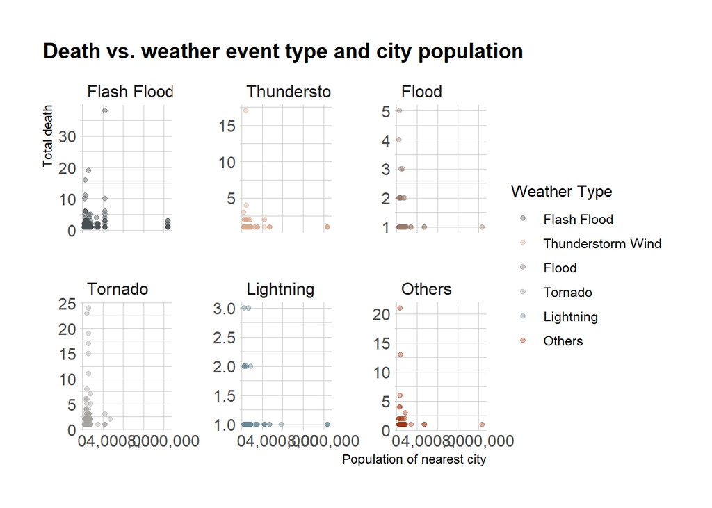

```r
library(hrbrthemes)

# Generate scatter plot
ggplot(weather_df, aes(x=Population, y=total_death)) +
  geom_point(aes(col=less_event_type), alpha=.4) +
  facet_wrap(~less_event_type, scales="free_y", ncol=3) +
  scale_x_continuous(labels=comma, breaks=seq(0, 8e6, 4e6)) +
  scale_color_manual("Weather Type", values=weather_colors) +
  labs(x="Population of nearest city", y="Total death",
       title="Death vs. weather event type and city population") +
  theme_ipsum() +
  theme(plot.title = element_text(size=15, hjust=.5, face="bold"),
        axis.title = element_text(size=13, face="bold"))
```